# Working Hours

Mark van der Sman

14 december 2017

The used dataset is acquired from [this Reddit post](https://www.reddit.com/r/DataVizRequests/comments/7jqso6/request_i_would_like_to_have_some_simple_graphs/) on DataViz Requests. For more information on the data, please read the post.

## Exploring the data

First some simple boxplots and scatterplots to get a general overview.

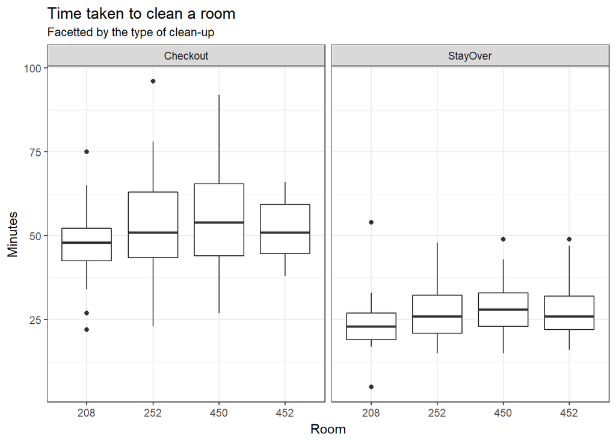

> This plot shows a clear difference between the time needed to clean a room upon checkout compared to the time needed for a stay-over.

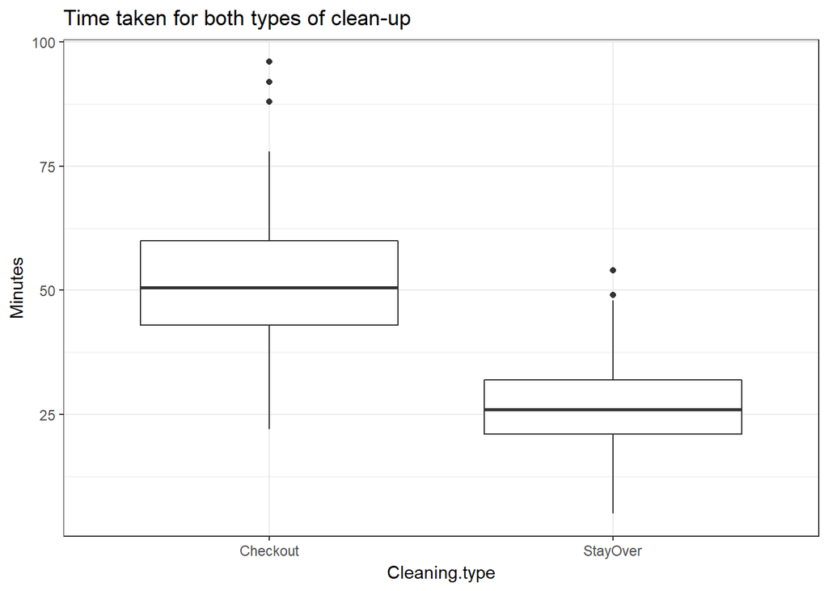

> The previous claim is supported by this plot, showing a clear difference between the two means of the types of cleaning.

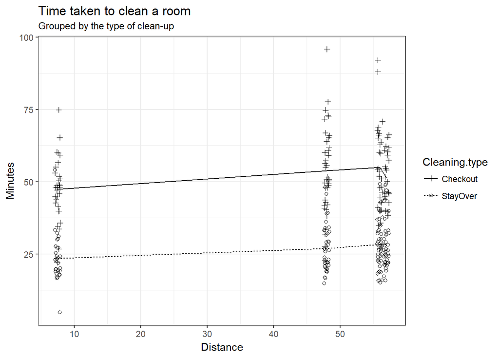

> The same conclusions can be drawn from this jitterplot

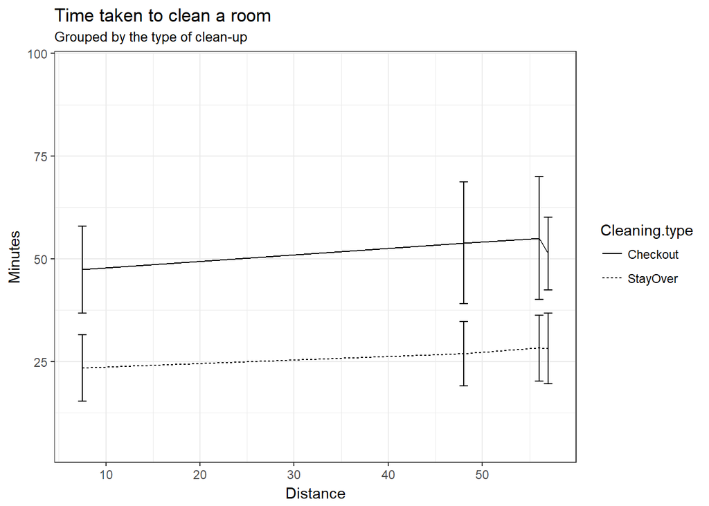

> Because of the density of some ranges, the errorbars (±1SD) were chosen for a cleaner plot. This suggests a clear difference between the two cleaning types. The distance does not, however, show any significant differences in the time measured other than an increase in variance for the longer distances.

## Correlation?

Let’s see if the correlation between Distance, Cleaning.type and Minutes is large enough.

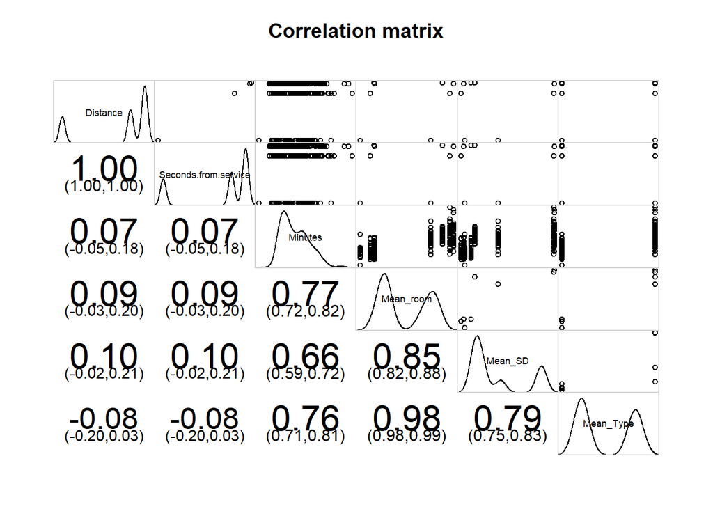

> The correlation table shows that the average cleaning time per room per type (Mean_room) is highly correlated with the average cleaning time per type (Mean_Type), indicating that the distance does not influence the cleaning time for a certain type. The low correlation of Distance with Minutes shows no relation between these two variables: the cleaning time is not influenced by the distance of a room.